# Exploratory Analysis

## High School Outcomes, race, and justice involvement

### Authors

Sara Mustre-del Rio, Amaya Whitney, Sander Lush, Li Lin

### Date

2/21/2022

### Abstract

Our team is interested in exploring the correlation between high school students’ race and their high school graduation rates in Washington. As part of the differences that we observe in the educational outcomes among different racial groups, we also want to find out other factors that could help explain these outcomes or correlate with them, such as Washington students’ involvement with the criminal justice system.

### Keywords

Race, demographic data, educational attainment, high school completion, criminal justice system

### Introduction

Education has always been one of the most concerning topics among the world. It is good to see that the educational attainment of the whole population has increased for the past few years. However, differences and gaps between the races still remain, or even worse, grow. In contemporary society, educational attainment could be one of the vital determinants of a person’s future path. To put it into the specific scenario, a decent education could help the person to have better job opportunities and the possibility to apply for higher wages. Beyond the economic elements, those who fail to graduate from high school are more likely to have health problems, worse housing, unhappy families, etc., compared with those who are “highly educated.”

If a person’s future is highly dependent on his/her educational attainment, and it would be affected by some demographic reasons; In other words, one’s future is determined by his/her ethnicity. The injustice a person will undergo is formed since his/her birth. As a bad consequence, it is undeniable that many situations like this would make people be disappointed and less confident about the meaning of education. Therefore, by focusing on Washington State, we would like to explore how demographic elements affect the educational result for high school students, the level that race is connected to high schoolers’ criminal justice system, and how they influence the educational outcomes when they are combined. Hopefully, it is possible to see if there is anything we can do to alleviate such inequality and the negative outcomes it brings.

### Related Work

Our team is researching the correlation between high school students’ race, their involvement with the criminal justice system and their educational outcomes to better understand the quantitative data behind sociological research and articles that discuss how punitive policies in K-12 public schools disproportionately affect students of color. *Police and punitive policies make schools less safe, especially for minority students*, an article written by Washington Post journalist Kathryn Schumaker, discusses how especially > “Black students [and students of color] are [much more likely to be suspended](https://www.pnas.org/content/116/17/8255), expelled or arrested at school than white students…mostly for minor infractions such as disrupting class or tardiness as opposed to criminal or violent behavior.” (Riddle and Sinclair, 2019) (Center for Civil Rights Remedies, 2019)

Research of this nature has developed new terms to define this social phenomena, such as the *school-to-prison pipeline* [(Heitzeg, 2009)](https://files.eric.ed.gov/fulltext/EJ870076.pdf). In her article Education Or Incarceration: Zero Tolerance Policies And The School To Prison Pipeline”, St. Catherine University professor Nancy A. Heitzeg defines the *school-to-prison pipeline* as a “growing pattern of tracking students out of educational institutions, primarily via ―zero tolerance policies, and tracking them directly and/or indirectly into the juvenile and adult criminal justice systems.”

The *school-to-prison pipeline* disproportionately affects marginalized communities such as low-income youth, students with disabilities, and youth of color, especially Black students. Black students are suspended and expelled at the highest rates, despite the lack of evidence to prove that Black students are more likely to misbehave under the same circumstances as their counterparts [(Witt, 2007)](https://www.chicagotribune.com/chi-070924discipline-story.html).

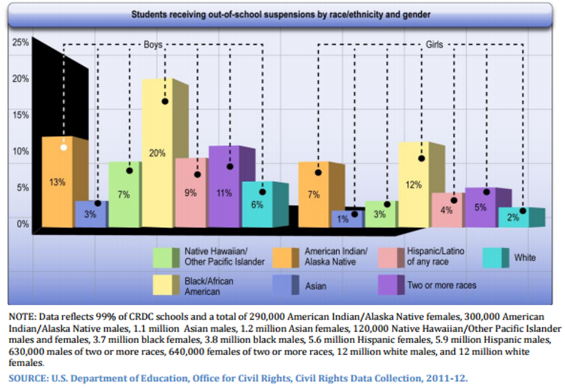

Bar graph showing U.S. high school students’ suspension rates by race and gender, in which Black male students have the highest rates

Source: [U.S. Department of Education, Office for Civil Rights, Civil Rights Data Collection, 2011-12](https://ocrdata.ed.gov)

### The Dataset

**Source**: [Juvenile Justice Dashboard - HS Completion](https://data.wa.gov/Education/Juvenile-Justice-Dashboard-HS-Completion/ej5m-hutb)

**Data Collection Method**: The Education Research and Data Center, an organization that collects data about Washington students, collected this data through demographic research and from data provided by multiple higher education institutions and groups, such as the OSPI P210 Enrollment Summary for information about high school graduates.

**Purpose of Data Collection**: The data was collected to provide information about secondary education outcomes for students who were involved in the criminal justice system.

**Number of Observations**: 921

**Number of Features**: 7

**Ethical Questions/Questions of Power**: - Are there international students in this data set who do not have records of graduation or a GED who are considered dropouts? - Are certain students left out who could have been included with a bit more research/structuring of the dataset? - In considering where the data from this specific dataset came from, how did the higher education institutions and groups collect their data? Are there any limitations or drawbacks in the methods that they are using?

**Limitations of the Dataset**: - Some of the values are blurred out to protect students’ identities, so it might skew the results. These might translate to N/A values in RStudio, so any function we use will need to exclude those values. - The data for students whose gender falls into the 'x' category is inconsistently recorded, which could result in inaccurate representation of this group.

### Implications

git Our research questions all aim to find answers about how race and involvement in with the criminal justice system affect education for high schoolers in Washington State. Because we are diving into the concept of race and education, this could have very controversial implications for policymakers in Washington, as education is a very important part in the upbringing of the next generation of minds that will be running our country one day. If it is found that race is a factor in the detriment of young people’s high school education experiences, and with that a direct connection to their involvement with the criminal justice system, this will prove to be a major flaw in our education and reform systems within Washington State. We will seek to find these answers in all ways that they factor into someone’s high school education, whether it be due to discrimination, lack of opportunity, school funding, or any other relevant factors that may contribute to an educational experience.

### Limitations & Challenges

There are a handful of different challenges and limitations that we will need to address in our research in order to come to a reliable conclusion. The first that comes to mind is the areas in which we choose to target within Washington state. Because school districts are usually controlled by the city or county that they reside in, it will be important to note any distinctions within these separate areas in order to identify any biases. This also applies to any data that we come across when conducting research about involvement with the criminal justice system and its effect on young people’s education outcomes. This could pose a challenge as the extra data that we are looking for may not be readily available in the way that we need it, forcing us to adapt based on the information that we know to be true. It is possible that educated inferences will need to be made for the sake of answering our research questions which could limit our findings. However, these are all challenges that can be addressed and should not keep us from answering our questions about the effects race and criminal justice involvement have on young people’s education outcomes in Washington State High Schools.

### Chart 1

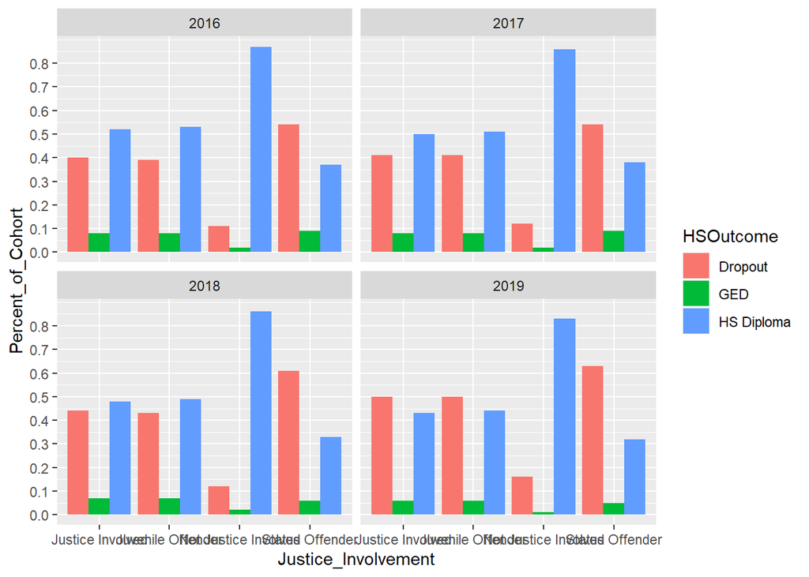

We wanted to demonstrate the changes over time for the high school outcomes for different types of justice involvement. These graphs show the percent for each high school outcome (GED, diploma, and dropout) for each type of justice involvement within different years.

### Chart 2

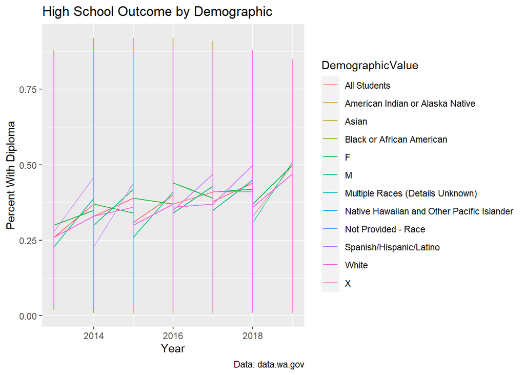

I chose to do this chart because it shows the percentage (slope) of students that graduated with a high school diploma based on their demographic values, and it is calculated per year. These values include race, sex, and all other unspecified values.

### Chart 3

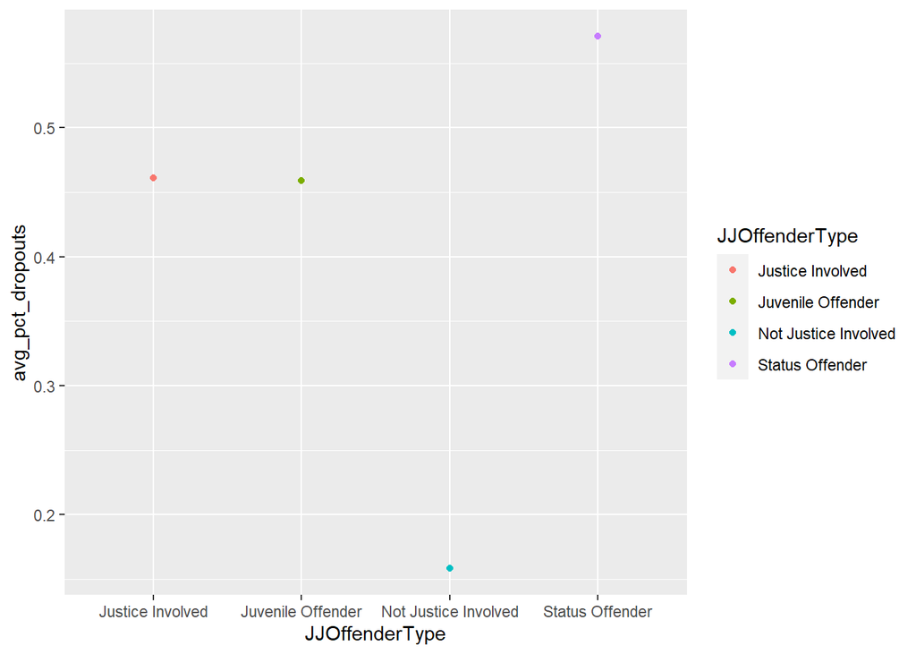

Demonstrates the average dropout rate per justice involvement category. We chose this chart to reveal how involvement with the criminal justice system might affect dropout rates.